# Section: Week 1

## Question 1

### 1.b-i)

**Calculate stats for maltreatment deaths:**

```r
deaths = c(11, 15, 15, 16, 25, 20)
m_deaths = mean(deaths)
s_deaths = sd(deaths)
var_deaths = var(deaths)
var_deaths_v2 = s_deaths^2
```

Over the period from 1990-1995, was a **mean** of 17 juvenile deaths per year caused by maltreatment. The **variance** in these maltreatment deaths was 23.6. The **standard deviation** of the same maltreatment deaths was 4.8579831.

### 1.b-ii)

**Calculate standard error of the mean:**

```r
n = length(deaths)
se_deaths = s_deaths/(sqrt(n))
```

For a sample of 6, the **standard error** of $\bar x$ = 1.9832633.

### 1.b-iii)

The algebraic equation for the estimated number (`T`) of maltreatment deaths in the period of `k` years is:

T = 17 * k

As `k` increases, the total (T) increases linearly as a function of the mean number of deaths (i.e., 17).

### 1.b-iv)

The standard deviation of the statistic (T) = `k *` sd(X). In this case, sd(X) is equal to the **standard error** of the sample mean ($\bar x$), calculated in **1b-ii**; thus sd(T) = `k *` 1.9832633.

### Example distributions using linear transformation:

```r
k = 1
year1 <- data.frame(length = rnorm(1000, mean = m_deaths, s_deaths))
k = 2
year2 <- year1 + data.frame(length = rnorm(1000, mean = m_deaths, s_deaths))
k = 3
year3 <- year2 + data.frame(length = rnorm(1000, mean = m_deaths, s_deaths))
```

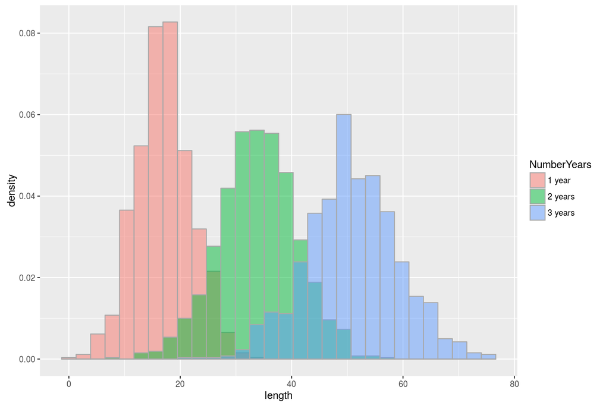

```r
#Now, combine your two dataframes into one.  First make a new column in each.
year1$NumberYears <- '1 year'
year2$NumberYears <- '2 years'
year3$NumberYears <- '3 years'

#and combine into your new data frame all_years
all_years <- rbind(year1, year2, year3)

library(ggplot2)
#now make your histogram
ggplot(all_years, aes(length, fill = NumberYears)) +
  geom_histogram(aes(y = ..density..),
                 alpha = 0.5,
                 colour = "darkgray",
                 position = 'identity')
```

### 1.b-v)

```r
death_data = data.frame(years=1:6,deaths=deaths)
```

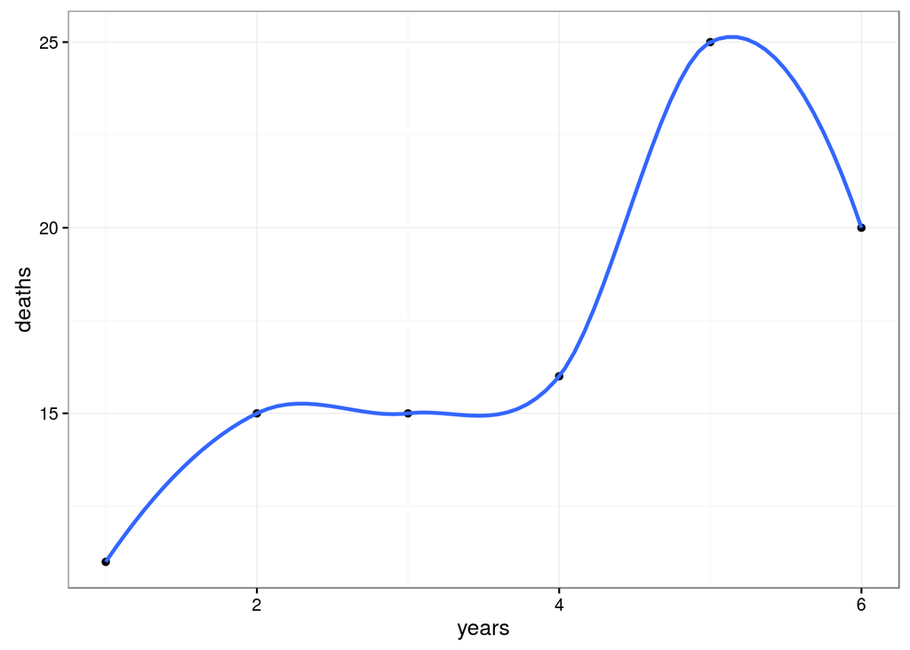

```r
ggplot(data = death_data,aes(x=years,y=deaths)) +
  geom_point() +
  geom_smooth() +
  theme_bw()
```

(Note: no confidence intervals because curve fits perfectly – switch to `geom_smooth(method='lm')` to see a confidence band)

## Question 2

### 2.a)

Here we will use the data in `earlydeaths.csv` to generate a **cross-tabulation**. This will indicate if there is a relationship between the variables `time` and `cause` (cause of death), which we will formally test in **2b**.

**Load in data:**

```r
# load in data
d0 = read.csv('http://stanford.edu/class/psych252/_downloads/earlydeaths.csv')
str(d0)
```

```
## 'data.frame':    350 obs. of  2 variables:
##  $ time : int  1 1 1 1 1 1 1 1 1 1 ...
##  $ cause: Factor w/ 2 levels "maltreat","other": 1 1 1 1 1 1 1 1 1 1 ...
```

```r
summary(d0)
```

```
##       time            cause
##  Min.   :1.000   maltreat:102
##  1st Qu.:1.000   other   :248
##  Median :2.000
##  Mean   :2.146
##  3rd Qu.:3.000
##  Max.   :3.000
```

**Change levels of `cause` to match the cross-tab in homework:**

```r
levels(d0$cause)
```

```
## [1] "maltreat" "other"
```

```r
levels(d0$cause)[1] = 'Maltreat'
levels(d0$cause)[2] = 'Non-Maltr'
levels(d0$cause)
```

```
## [1] "Maltreat"  "Non-Maltr"
```

**Generate cross-tabulation of `time` by `cause`:**

```r
# Print the table
print(table(d0$cause, d0$time))
```

```
##
##               1   2   3
##   Maltreat   26  31  45
##   Non-Maltr  68  80 100
```

```r
# Print table with margins, like in hw
tx = addmargins(table(d0$cause, d0$time, dnn=c('Cause','Time')))
print(tx)
```

```
##            Time
## Cause         1   2   3 Sum
##   Maltreat   26  31  45 102
##   Non-Maltr  68  80 100 248
##   Sum        94 111 145 350
```

### 2.b)

```r
# Print the table summary (i.e., chi-squared contingency test)
rs1 = summary(table(d0$cause, d0$time))
print(rs1)
```

```
## Number of cases in table: 350
## Number of factors: 2
## Test for independence of all factors:
##  Chisq = 0.4308, df = 2, p-value = 0.8062
```

```r
# access variables from this output "object"
chisq = rs1$statistic
df = rs1$parameter
pval = rs1$p.value
```

To test the null hypothesis that there is no relationship between the cause of juvenile deaths (`cause`) and time (`time`), we conducted a **chi-squared contingency test**. Results indicate that there is not a significant relationship between the cause of deaths and time, $\chi^2$(2) = 0.4307547, *p* = 0.8062371. In other words, the time trend in the number of deaths is similar regardless of the cause of death.

**n.b., you can write stats output in the following ways:** $\chi^2$(2) = 0.4307547, *p* = 0.8062371; X^2 (2) = 0.43, *p* = 0.81.

If you decide to use latex, [this site](http://www.calvin.edu/~rpruim/courses/m343/F12/RStudio/LatexExamples.html) is a helpful resource!

## Question 8

### 8.a)

**Create variable storing population size for age ranges:**

```r
census_pop = c(72.3, 46.5, 43.2, 42.5, 41.9, 35)
```

**Calculate size of sub-population >18 years old:**

```r
pop_Over18 = sum(census_pop) - census_pop[1]
```

The size of the sub-population of likely voters is 209.1.

**Calculate proportion of likely voters by age category:**

```r
p_likelyvoters = census_pop[2:6]/pop_Over18
```

The proportions of likely voters for the age categories over 18 are: 0.2223816, 0.2065997, 0.203252, 0.2003826, 0.167384.

### 8.b)

**Load in data from fieldsimul1.csv:**

```r
d1 = read.csv('http://stanford.edu/class/psych252/_downloads/fieldsimul1.csv')
str(d1)
```

```
## 'data.frame':    200 obs. of  7 variables:
##  $ recall : int  1 1 1 1 1 1 1 1 1 1 ...
##  $ prop54 : int  1 1 1 1 1 1 1 1 1 1 ...
##  $ party  : int  1 1 1 1 1 1 1 1 1 1 ...
##  $ age    : int  49 44 46 50 25 28 21 20 22 73 ...
##  $ optmism: int  7 8 7 7 6 7 5 5 6 8 ...
##  $ agecat : int  45 45 45 45 24 24 24 24 24 70 ...
##  $ recallq: int  1 1 1 1 1 1 1 1 1 1 ...
```

```r
summary(d1)
```

```
##      recall         prop54          party           age
##  Min.   :1.00   Min.   :1.000   Min.   :1.00   Min.   :20.00
##  1st Qu.:1.00   1st Qu.:1.000   1st Qu.:1.00   1st Qu.:37.00
##  Median :1.00   Median :2.000   Median :2.00   Median :48.00
##  Mean   :1.51   Mean   :1.785   Mean   :1.75   Mean   :48.32
##  3rd Qu.:2.00   3rd Qu.:2.000   3rd Qu.:2.00   3rd Qu.:58.00
##  Max.   :3.00   Max.   :3.000   Max.   :3.00   Max.   :75.00
##     optmism           agecat         recallq
##  Min.   : 0.000   Min.   :24.00   Min.   :-1.000
##  1st Qu.: 4.000   1st Qu.:35.00   1st Qu.:-1.000
##  Median : 6.000   Median :45.00   Median : 1.000
##  Mean   : 5.615   Mean   :48.12   Mean   : 0.115
##  3rd Qu.: 7.000   3rd Qu.:57.00   3rd Qu.: 1.000
##  Max.   :11.000   Max.   :70.00   Max.   : 1.000
```

**Recode age into categorical variable using 5 age categories:**

```r
d1$agecat0 = findInterval(d1$age, c(30,40,50,66))
d1$agecat0 = d1$agecat0 + 1     # group 1 starts at 1
d1$agecat0 = factor(d1$agecat0) # convert to categorical var
head(d1)
```

```
##   recall prop54 party age optmism agecat recallq agecat0
## 1      1      1     1  49       7     45       1       3
## 2      1      1     1  44       8     45       1       3
## 3      1      1     1  46       7     45       1       3
## 4      1      1     1  50       7     45       1       4
## 5      1      1     1  25       6     24       1       1
## 6      1      1     1  28       7     24       1       1
```

### 8.c)

```r
rs4 = chisq.test(table(d1$agecat0), p = p_likelyvoters, simulate.p.value = FALSE)
print(rs4)
```

```
##
##  Chi-squared test for given probabilities
##
## data:  table(d1$agecat0)
## X-squared = 19.883, df = 4, p-value = 0.0005268
```

```r
# Note this format also gives the same results:
rs4_v2 = chisq.test(table(d1$agecat0), p = census_pop[2:6], rescale.p = TRUE, simulate.p.value = FALSE)
print(rs4_v2)
```

```
##
##  Chi-squared test for given probabilities
##
## data:  table(d1$agecat0)
## X-squared = 19.883, df = 4, p-value = 0.0005268
```

Explain results….

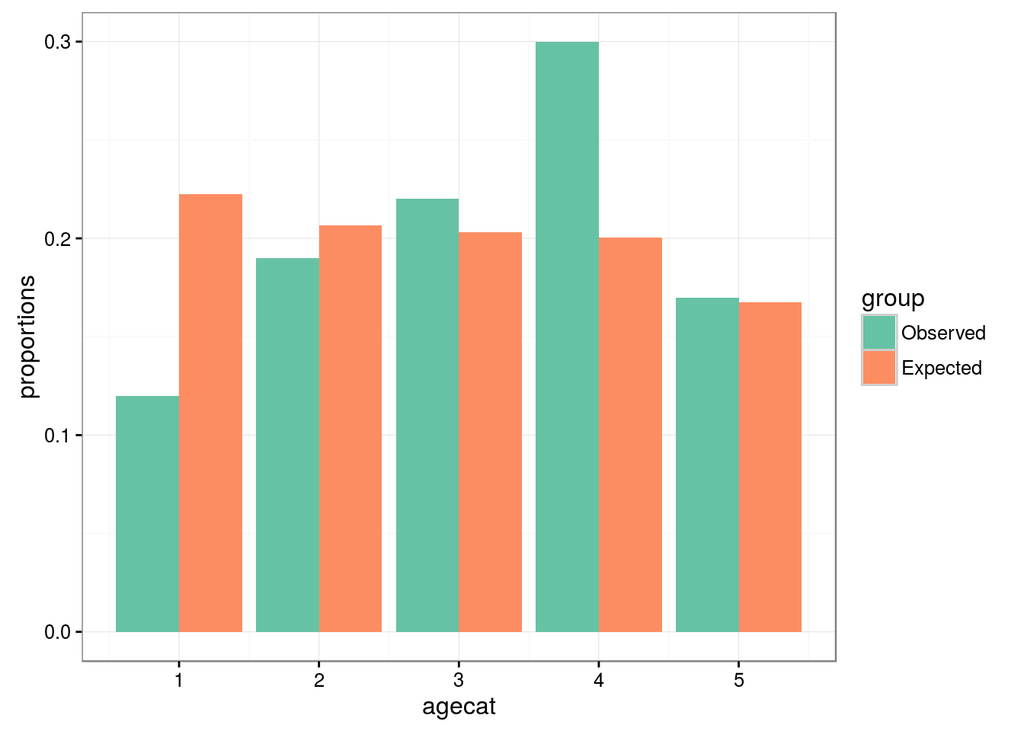

```r
p_observed = table(d1$agecat0)/length(d1$agecat0)
p_expected = p_likelyvoters

df_cat = data.frame(proportions=c(p_observed, p_expected),
                    agecat=c(1,2,3,4,5,1,2,3,4,5),
                    group=factor(c(-1,-1,-1,-1,-1,1,1,1,1,1),
                                 labels=c("Observed","Expected")))

ggplot(df_cat) +
  geom_bar(aes(x=agecat, y=proportions, fill=group),
           stat="identity",
           position="dodge") +
  scale_fill_brewer(palette="Set2") +
  theme_bw()
```

### 8.d)

```r
d1$party = factor(d1$party)
levels(d1$party) = c('Dem', 'Rep', 'Other')

d1$recall = factor(d1$recall)
levels(d1$recall) = c('Yes', 'No', 'Unsure')

head(d1)
```

```
##   recall prop54 party age optmism agecat recallq agecat0
## 1    Yes      1   Dem  49       7     45       1       3
## 2    Yes      1   Dem  44       8     45       1       3
## 3    Yes      1   Dem  46       7     45       1       3
## 4    Yes      1   Dem  50       7     45       1       4
## 5    Yes      1   Dem  25       6     24       1       1
## 6    Yes      1   Dem  28       7     24       1       1
```

```r
table(d1$recall, d1$party)
```

```
##
##          Dem Rep Other
##   Yes     40  49    18
##   No      43  25    16
##   Unsure   3   4     2
```

```r
# Print table with margins
tx = addmargins(table(d1$recall, d1$party, dnn=c('Recall','Party')))
print(tx)
```

```
##         Party
## Recall   Dem Rep Other Sum
##   Yes     40  49    18 107
##   No      43  25    16  84
##   Unsure   3   4     2   9
##   Sum     86  78    36 200
```

```r
# Run chi-squared test
rs5 = chisq.test(table(d1$recall, d1$party))
print(rs5)
```

```
##
##  Pearson's Chi-squared test
##
## data:  table(d1$recall, d1$party)
## X-squared = 5.687, df = 4, p-value = 0.2238
```

Explain results…

```r
d3 = d1[d1$recall != 'Unsure',]
str(d3) # note the 3 levels of recall still!
```

```
## 'data.frame':    191 obs. of  8 variables:
##  $ recall : Factor w/ 3 levels "Yes","No","Unsure": 1 1 1 1 1 1 1 1 1 1 ...
##  $ prop54 : int  1 1 1 1 1 1 1 1 1 1 ...
##  $ party  : Factor w/ 3 levels "Dem","Rep","Other": 1 1 1 1 1 1 1 1 1 1 ...
##  $ age    : int  49 44 46 50 25 28 21 20 22 73 ...
##  $ optmism: int  7 8 7 7 6 7 5 5 6 8 ...
##  $ agecat : int  45 45 45 45 24 24 24 24 24 70 ...
##  $ recallq: int  1 1 1 1 1 1 1 1 1 1 ...
##  $ agecat0: Factor w/ 5 levels "1","2","3","4",..: 3 3 3 4 1 1 1 1 1 5 ...
```

```r
d3$recall = factor(d3$recall)

rs6 = chisq.test(table(d3$recall, d3$party))
print(rs6)
```

```
##
##  Pearson's Chi-squared test
##
## data:  table(d3$recall, d3$party)
## X-squared = 5.3173, df = 2, p-value = 0.07004
```

Explain results…

## 8.e)

**Re-code recall as quantitative variable:**

```r
d1$recallq = as.numeric(d1$recall)
d1$recallq = 1*as.numeric(d1$recallq==1) + (-1)*as.numeric(d1$recallq==2) + 0*as.numeric(d1$recallq==3)

summary(d1)
```

```
##     recall        prop54        party         age           optmism
##  Yes   :107   Min.   :1.000   Dem  :86   Min.   :20.00   Min.   : 0.000
##  No    : 84   1st Qu.:1.000   Rep  :78   1st Qu.:37.00   1st Qu.: 4.000
##  Unsure:  9   Median :2.000   Other:36   Median :48.00   Median : 6.000
##               Mean   :1.785              Mean   :48.32   Mean   : 5.615
##               3rd Qu.:2.000              3rd Qu.:58.00   3rd Qu.: 7.000
##               Max.   :3.000              Max.   :75.00   Max.   :11.000
##      agecat         recallq       agecat0
##  Min.   :24.00   Min.   :-1.000   1:24
##  1st Qu.:35.00   1st Qu.:-1.000   2:38
##  Median :45.00   Median : 1.000   3:44
##  Mean   :48.12   Mean   : 0.115   4:60
##  3rd Qu.:57.00   3rd Qu.: 1.000   5:34
##  Max.   :70.00   Max.   : 1.000
```

## 8.f)

```r
library(dplyr)
```

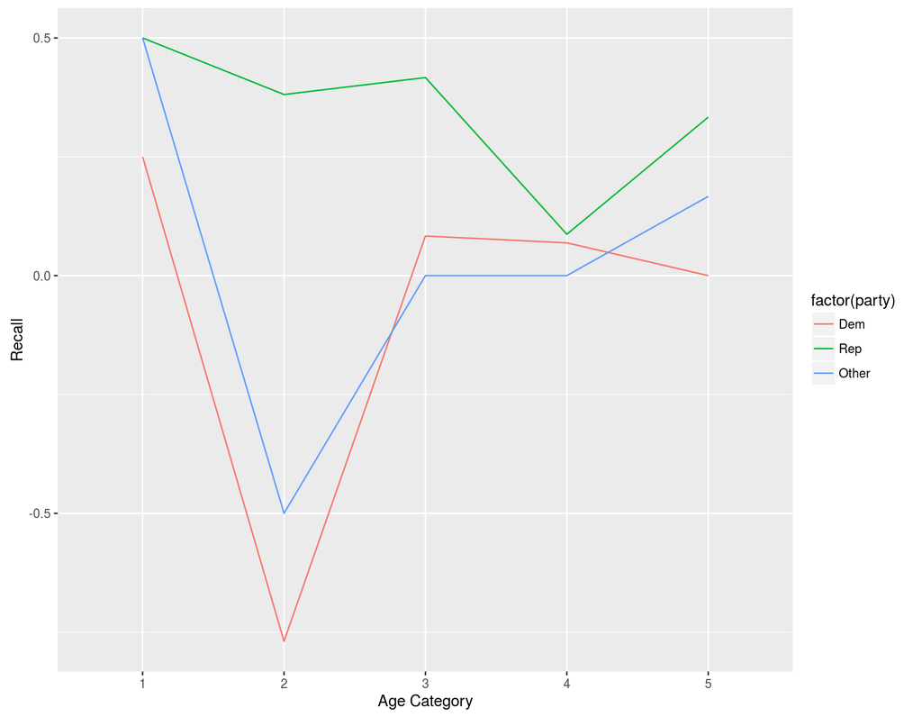

```r
d1 %>%
  group_by(agecat0,party) %>%
  summarise(mu = mean(recallq)) %>%
  ggplot(data=., aes(x=agecat0, y=mu, color=factor(party), group=factor(party))) +
  geom_line() +
  xlab("Age Category") +
  ylab("Recall")
```

```r
## If you prefer not to use dplyr, use this code:
# interaction.plot(d1$agecat0, d1$party, d1$recallq,
#                 xlab = 'Age Category', ylab = 'Recall')
```

## 8.g)

```r
str(d1)
```

```
## 'data.frame':    200 obs. of  8 variables:
##  $ recall : Factor w/ 3 levels "Yes","No","Unsure": 1 1 1 1 1 1 1 1 1 1 ...
##  $ prop54 : int  1 1 1 1 1 1 1 1 1 1 ...
##  $ party  : Factor w/ 3 levels "Dem","Rep","Other": 1 1 1 1 1 1 1 1 1 1 ...
##  $ age    : int  49 44 46 50 25 28 21 20 22 73 ...
##  $ optmism: int  7 8 7 7 6 7 5 5 6 8 ...
##  $ agecat : int  45 45 45 45 24 24 24 24 24 70 ...
##  $ recallq: num  1 1 1 1 1 1 1 1 1 1 ...
##  $ agecat0: Factor w/ 5 levels "1","2","3","4",..: 3 3 3 4 1 1 1 1 1 5 ...
```

```r
# additive model
rs_add = lm(recallq ~ agecat0 + party, data = d1)
summary(rs_add)
```

```
##
## Call:
## lm(formula = recallq ~ agecat0 + party, data = d1)
##
## Residuals:
##     Min      1Q  Median      3Q     Max
## -1.6637 -1.0104  0.5741  0.9091  1.3417
##
## Coefficients:
##             Estimate Std. Error t value Pr(>|t|)
## (Intercept)  0.25116    0.20179   1.245  0.21476
## agecat02    -0.59286    0.25677  -2.309  0.02201 *
## agecat03    -0.24080    0.25100  -0.959  0.33857
## agecat04    -0.35335    0.23405  -1.510  0.13275
## agecat05    -0.23473    0.25850  -0.908  0.36498
## partyRep     0.41249    0.15720   2.624  0.00939 **
## partyOther   0.08055    0.19373   0.416  0.67804
## ---
## Signif. codes:  0 '***' 0.001 '**' 0.01 '*' 0.05 '.' 0.1 ' ' 1
##
## Residual standard error: 0.9598 on 193 degrees of freedom
## Multiple R-squared:  0.05608,    Adjusted R-squared:  0.02673
## F-statistic: 1.911 on 6 and 193 DF,  p-value: 0.08086
```

```r
# interactive model
rs_inter = lm(recallq ~ agecat0 * party, data = d1)
summary(rs_inter)
```

```
##
## Call:
## lm(formula = recallq ~ agecat0 * party, data = d1)
##
## Residuals:
##     Min      1Q  Median      3Q     Max
## -1.5000 -1.0690  0.5833  0.8333  1.7692
##
## Coefficients:
##                     Estimate Std. Error t value Pr(>|t|)
## (Intercept)          0.25000    0.24014   1.041  0.29921
## agecat02            -1.01923    0.35867  -2.842  0.00499 **
## agecat03            -0.16667    0.36682  -0.454  0.65011
## agecat04            -0.18103    0.29914  -0.605  0.54580
## agecat05            -0.25000    0.33961  -0.736  0.46258
## partyRep             0.25000    0.53697   0.466  0.64207
## partyOther           0.25000    0.53697   0.466  0.64207
## agecat02:partyRep    0.90018    0.63502   1.418  0.15800
## agecat03:partyRep    0.08333    0.63536   0.131  0.89579
## agecat04:partyRep   -0.23201    0.60023  -0.387  0.69955
## agecat05:partyRep    0.08333    0.70696   0.118  0.90629
## agecat02:partyOther  0.01923    0.76811   0.025  0.98005
## agecat03:partyOther -0.33333    0.69323  -0.481  0.63120
## agecat04:partyOther -0.31897    0.65992  -0.483  0.62943
## agecat05:partyOther -0.08333    0.65031  -0.128  0.89817
## ---
## Signif. codes:  0 '***' 0.001 '**' 0.01 '*' 0.05 '.' 0.1 ' ' 1
##
## Residual standard error: 0.9606 on 185 degrees of freedom
## Multiple R-squared:  0.09374,    Adjusted R-squared:  0.02516
## F-statistic: 1.367 on 14 and 185 DF,  p-value: 0.1731
```

```r
# quadratic trend of age?
d1$agecat0 = as.numeric(d1$agecat0)
str(d1)
```

```
## 'data.frame':    200 obs. of  8 variables:
##  $ recall : Factor w/ 3 levels "Yes","No","Unsure": 1 1 1 1 1 1 1 1 1 1 ...
##  $ prop54 : int  1 1 1 1 1 1 1 1 1 1 ...
##  $ party  : Factor w/ 3 levels "Dem","Rep","Other": 1 1 1 1 1 1 1 1 1 1 ...
##  $ age    : int  49 44 46 50 25 28 21 20 22 73 ...
##  $ optmism: int  7 8 7 7 6 7 5 5 6 8 ...
##  $ agecat : int  45 45 45 45 24 24 24 24 24 70 ...
##  $ recallq: num  1 1 1 1 1 1 1 1 1 1 ...
##  $ agecat0: num  3 3 3 4 1 1 1 1 1 5 ...
```

```r
# additive model w/quadratic effect of age category
rs_add_polyage = lm(recallq ~ poly(agecat0, 2) + party, data = d1)
summary(rs_add_polyage)
```

```
##
## Call:
## lm(formula = recallq ~ poly(agecat0, 2) + party, data = d1)
##
## Residuals:
##     Min      1Q  Median      3Q     Max
## -1.4918 -0.9895  0.6190  0.8572  1.1413
##
## Coefficients:
##                   Estimate Std. Error t value Pr(>|t|)
## (Intercept)       -0.05310    0.10530  -0.504   0.6147
## poly(agecat0, 2)1 -0.10377    0.97538  -0.106   0.9154
## poly(agecat0, 2)2  1.20075    1.01011   1.189   0.2360
## partyRep           0.39074    0.15672   2.493   0.0135 *
## partyOther         0.08727    0.19293   0.452   0.6515
## ---
## Signif. codes:  0 '***' 0.001 '**' 0.01 '*' 0.05 '.' 0.1 ' ' 1
##
## Residual standard error: 0.9663 on 195 degrees of freedom
## Multiple R-squared:  0.03341,    Adjusted R-squared:  0.01358
## F-statistic: 1.685 on 4 and 195 DF,  p-value: 0.155
```

```r
# interactive model w/quadratic effect of age category
rs_inter_polyage = lm(recallq ~ poly(agecat0, 2) * party, data = d1)
summary(rs_inter_polyage)
```

```
##
## Call:
## lm(formula = recallq ~ poly(agecat0, 2) * party, data = d1)
##
## Residuals:
##     Min      1Q  Median      3Q     Max
## -1.5382 -0.9369  0.5904  0.8399  1.1722
##
## Coefficients:
##                              Estimate Std. Error t value Pr(>|t|)
## (Intercept)                  -0.05575    0.10706  -0.521   0.6031
## poly(agecat0, 2)1             0.72129    1.36832   0.527   0.5987
## poly(agecat0, 2)2             1.45013    1.44534   1.003   0.3170
## partyRep                      0.35708    0.16244   2.198   0.0291 *
## partyOther                    0.07521    0.20123   0.374   0.7090
## poly(agecat0, 2)1:partyRep   -2.41172    2.34781  -1.027   0.3056
## poly(agecat0, 2)2:partyRep   -1.20838    2.47568  -0.488   0.6260
## poly(agecat0, 2)1:partyOther -0.98858    2.61270  -0.378   0.7056
## poly(agecat0, 2)2:partyOther  0.66763    2.59544   0.257   0.7973
## ---
## Signif. codes:  0 '***' 0.001 '**' 0.01 '*' 0.05 '.' 0.1 ' ' 1
##
## Residual standard error: 0.9725 on 191 degrees of freedom
## Multiple R-squared:  0.04092,    Adjusted R-squared:  0.0007485
## F-statistic: 1.019 on 8 and 191 DF,  p-value: 0.4233
```

Explain output…